# NYCFlights: Arrival Delay Logictic Model

Nimish Kulkarni

23 October 2016

## Logsitic and Inverse Logistic Transformation

- Write an R function for the logistic function. The function should accept a `numeric` vector with values `[-Inf,Inf]` and produce a numeric vector in the the range `[0,1]`. Plot the logistic function from `[-10,10]`
- Write a R function for the inverse logistic function. The function should accept a `numeric` vector with values `[0,1]` and prodcuce a numeric vector in the range `[-Inf,Inf]` Plot the Inverse Logistic function from `[0,1]`

**Hint:** For plotting curves see `?graphics::curve` or `?ggplot2::stat_function`

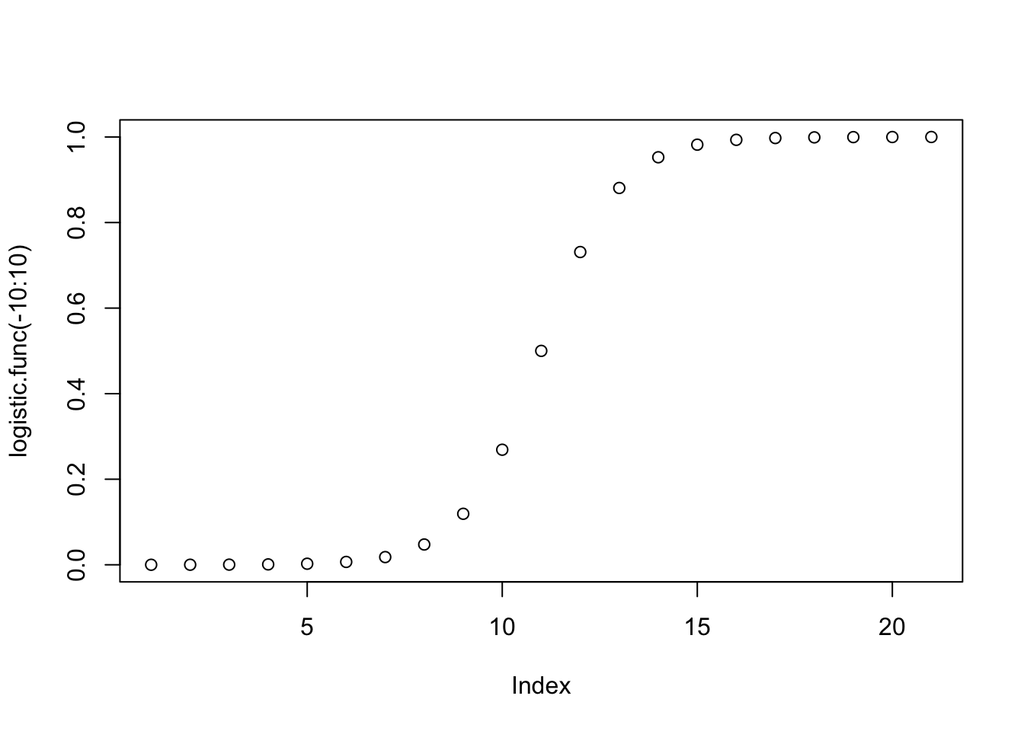

```r
logistic.func <- function(x) {
  1 / (1 + exp(-x))
}
plot(logistic.func(-10:10))
```

```r
inv.logistic.func <- function(x) {
  log(x/(1-x))
}
logistic.func(10)
```

```
## [1] 0.9999546
```

```r
inv.logistic.func(0.9999546)
```

```
## [1] 9.999953
```

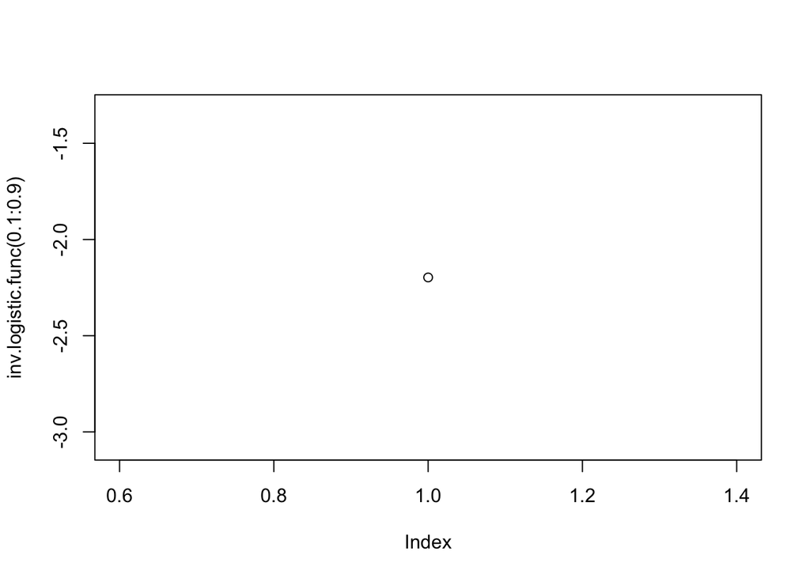

```r
plot(inv.logistic.func(0.1:0.9))
```

# NYCFlights Model

Using the rectangular data that you created from assignment and following the *Predicting Medical Expenses* example from the text (*MLwR*), create a model for arr_delay >= 15 minutes. Follow *MLwR* structure for building a model. Describe/Explain each of the steps and show all work in codeblocks below.

KNIT YOUR DOCUMENT AS *HTML* AND SUBMIT IT AND THE `Rmd` file.

## Step 1: Collect Data

```r
# Data Frames

flights  <- "../data/flights.csv" %>% read_csv
planes   <- read_csv("../data/planes.csv")
airports <- read_csv("../data/airports.csv")
weather  <- read_csv("../data/weather.csv")
# Merging Data Frames
YX <- flights

## planes
YX <- merge( YX, planes, by="tailnum", all.x = TRUE, suffixes=c("", ".pl") )

## airports
YX <- merge(YX, airports, by.x="origin", by.y="faa", all.x=TRUE, suffixes=c("", ".origin")  )
YX <- merge(YX, airports, by.x="dest", by.y="faa", all.x=TRUE, suffixes=c("", ".dest")  )

## weather
# weather$date <- ymd(weather$year, weather$month, weather$day)
YX <-
  merge( YX, weather, by=c("origin","year","month","day","hour"), all.x=TRUE, suffixes=c('',".weather") )

## clearing the console screen
cat("\014")
```

## Step 2: Explore and Prep The Data

One of the things not done in the MLwR text is a pairwise comparison between the response and each of the predictors. Make sure to do this; this is often very illustrative of the relationship between that predictor and the response. This can be done with `pairs` or `psych::panel.pairs`

```r
yx <- copy(YX)

#copying arr_delay as new column to perform transformations
yx$arr_delay_new <- yx$arr_delay

summary(yx$arr_delay_new)
```

```
##     Min.  1st Qu.   Median     Mean  3rd Qu.     Max.     NA's
##  -86.000  -17.000   -5.000    6.895   14.000 1272.000     9430
```

```r
# handling NA values , thinking to replace with mean but since mean is less than 15 minutes
# assigning 0 class
yx["arr_delay_new"][is.na(yx["arr_delay_new"])] <- 0

# if arr_delay < 15 minutes then 0
yx["arr_delay_new"][yx["arr_delay_new"] < 15] <- 0

# assigning classes if arr_delay >= 15 minutes then 1
yx["arr_delay_new"][yx["arr_delay_new"] >= 15] <- 1



# commenting test code
# count = 0
# for (val in yx$arr_delay_new) {
#     if(val >= 15)  {
#       print(val)
#       count = count+1
#     }
# }
# print(count)
```

## Step 3: Train The Model

```r
logModel1 <- glm( yx$arr_delay_new ~ yx$temp + yx$dewp + yx$humid + yx$dep_time , data = yx, family = "binomial")


yx[c("year","month","day","hour","dep_time","sched_dep_time","dep_delay","arr_time","sched_arr_time","air_time","distance","minute","temp", "dewp", "humid","wind_dir","wind_speed","wind_gust","precip","pressure","visib")][is.na(
  yx[c("year","month","day","hour","dep_time","sched_dep_time","dep_delay","arr_time","sched_arr_time","air_time","distance","minute","temp", "dewp", "humid","wind_dir","wind_speed","wind_gust","precip","pressure","visib")]
)] <- 0

logModel2 <- glm( yx$arr_delay_new ~ yx$dep_time + yx$sched_dep_time + yx$dep_delay + yx$arr_time + yx$air_time + yx$distance+ yx$temp + yx$wind_dir + yx$precip + yx$pressure + yx$visib + yx$dewp)

# model for part B , preparing it here
logModel3 <- glm( yx$arr_delay_new ~ yx$dep_time + yx$sched_dep_time + yx$temp + yx$wind_dir + yx$precip + yx$pressure + yx$dewp)
```

## Step 4: Evaluate Performance

Think about some of the tools that you have for evaluating performance. Choose one and articulate why you have chosen it.

```r
summary(logModel1)
```

```
##
## Call:
## glm(formula = yx$arr_delay_new ~ yx$temp + yx$dewp + yx$humid +
##     yx$dep_time, family = "binomial", data = yx)
##
## Deviance Residuals:
##     Min       1Q   Median       3Q      Max
## -1.7320  -0.7546  -0.5952  -0.3396   2.8917
##
## Coefficients:
##               Estimate Std. Error z value Pr(>|z|)
## (Intercept) -5.402e+00  1.004e-01 -53.811  < 2e-16 ***
## yx$temp      1.672e-02  2.397e-03   6.978 2.99e-12 ***
## yx$dewp     -1.913e-02  2.542e-03  -7.525 5.27e-14 ***
## yx$humid     3.040e-02  1.163e-03  26.131  < 2e-16 ***
## yx$dep_time  1.583e-03  1.029e-05 153.816  < 2e-16 ***
## ---
## Signif. codes:  0 '***' 0.001 '**' 0.01 '*' 0.05 '.' 0.1 ' ' 1
##
## (Dispersion parameter for binomial family taken to be 1)
##
##     Null deviance: 363576  on 327302  degrees of freedom
## Residual deviance: 334638  on 327298  degrees of freedom
##   (9473 observations deleted due to missingness)
## AIC: 334648
##
## Number of Fisher Scoring iterations: 4
```

```r
summary(logModel2)
```

```
##
## Call:
## glm(formula = yx$arr_delay_new ~ yx$dep_time + yx$sched_dep_time +
##     yx$dep_delay + yx$arr_time + yx$air_time + yx$distance +
##     yx$temp + yx$wind_dir + yx$precip + yx$pressure + yx$visib +
##     yx$dewp)
##
## Deviance Residuals:
##     Min       1Q   Median       3Q      Max
## -6.9395  -0.1791  -0.1197  -0.0276   1.6406
##
## Coefficients:
##                     Estimate Std. Error t value Pr(>|t|)
## (Intercept)        7.995e-02  3.800e-03  21.037  < 2e-16 ***
## yx$dep_time        6.539e-06  2.781e-06   2.351 0.018709 *
## yx$sched_dep_time  7.868e-05  2.705e-06  29.083  < 2e-16 ***
## yx$dep_delay       6.022e-03  1.554e-05 387.574  < 2e-16 ***
## yx$arr_time        1.191e-05  1.481e-06   8.040 9.05e-16 ***
## yx$air_time        2.689e-03  2.760e-05  97.441  < 2e-16 ***
## yx$distance       -3.463e-04  3.521e-06 -98.343  < 2e-16 ***
## yx$temp           -1.890e-03  9.370e-05 -20.172  < 2e-16 ***
## yx$wind_dir       -1.961e-05  5.334e-06  -3.676 0.000237 ***
## yx$precip          3.500e-01  2.984e-02  11.728  < 2e-16 ***
## yx$pressure       -1.801e-05  2.091e-06  -8.612  < 2e-16 ***
## yx$visib          -5.714e-03  3.320e-04 -17.211  < 2e-16 ***
## yx$dewp            2.272e-03  8.753e-05  25.957  < 2e-16 ***
## ---
## Signif. codes:  0 '***' 0.001 '**' 0.01 '*' 0.05 '.' 0.1 ' ' 1
##
## (Dispersion parameter for gaussian family taken to be 0.1107322)
##
##     Null deviance: 61049  on 336775  degrees of freedom
## Residual deviance: 37291  on 336763  degrees of freedom
## AIC: 214621
##
## Number of Fisher Scoring iterations: 2
```

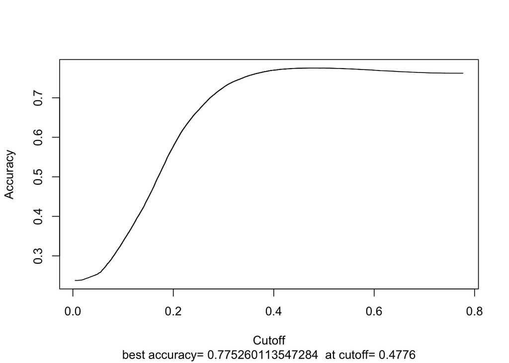

```r
#confint(logModel1)
#confint(logModel2)

predictions <- predict(logModel1, newdata = yx, type="response")
labels <- yx$arr_delay_new

require(ROCR)
# Prepare data for plotting

pred <- with(yx, prediction(predictions, labels))
perf <- performance(pred, measure="acc", x.measure="cutoff")

# Get the cutoff for the best accuracy
bestAccInd <- which.max(perf@"y.values"[[1]])
bestMsg <- paste("best accuracy=", perf@"y.values"[[1]][bestAccInd],
              " at cutoff=", round(perf@"x.values"[[1]][bestAccInd], 4))

plot(perf, sub=bestMsg)
```

```r
# deleting the labels from data
yx <- subset(yx, select = -c(arr_delay_new) )


predictions <- predict(logModel1, newdata = yx, type="response")
predictions <- round(predictions)
mean(predictions==labels)
```

```
## [1] 0.7750938
```

```r
predictions <- predict(logModel2, newdata = yx, type="response")
predictions <- round(predictions)
mean(predictions==labels)
```

```
## [1] 0.8500962
```

## Step 5: Improve Performance

Show some steps for improving model performance.

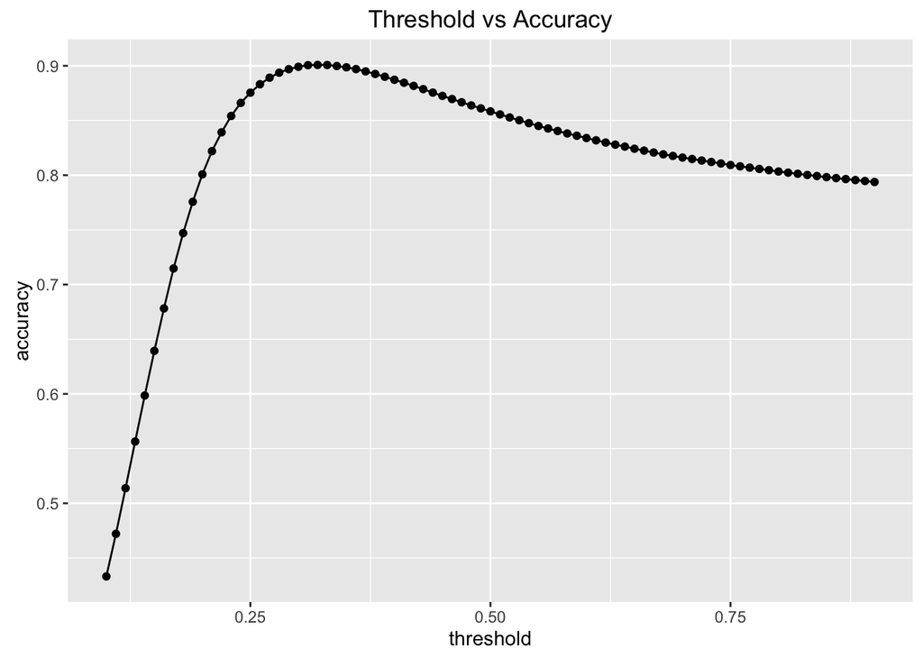

```r
# Model 2 has the highest accuracy of 90% around threshold of 0.3
library(ggplot2)
threshold <- seq(from=0.1,to=0.9,by=0.01)
j <- 1
accuracy <-c()
for(i in threshold){
  predictions <- predict(logModel2,newdata=yx,type = 'response')
  predictions <- ifelse(predictions>i,1,0)
  accuracy[j] <- mean(predictions==labels)
  j=j+1

}
model_accuracy <- data.frame(threshold,accuracy)
(ggplot(model_accuracy,aes(x=threshold,y = accuracy))+geom_line()+geom_point()+ggtitle("Threshold vs Accuracy"))
```

```r
kable(model_accuracy %>% arrange(desc(accuracy)))
```

| threshold | accuracy |
| --- | --- |
| 0.32 | 0.9008213 |
| 0.33 | 0.9007471 |
| 0.31 | 0.9005986 |
| 0.34 | 0.8997999 |
| 0.30 | 0.8991258 |
| 0.35 | 0.8986478 |
| 0.36 | 0.8970206 |
| 0.29 | 0.8969404 |
| 0.37 | 0.8949123 |
| 0.28 | 0.8937484 |
| 0.38 | 0.8925784 |
| 0.39 | 0.8900129 |
| 0.27 | 0.8891578 |
| 0.40 | 0.8872604 |
| 0.41 | 0.8845523 |
| 0.26 | 0.8831686 |
| 0.42 | 0.8816632 |
| 0.43 | 0.8786849 |
| 0.44 | 0.8755167 |
| 0.25 | 0.8754454 |
| 0.45 | 0.8725176 |
| 0.46 | 0.8696255 |
| 0.47 | 0.8666948 |
| 0.24 | 0.8661068 |
| 0.48 | 0.8638175 |
| 0.49 | 0.8610916 |
| 0.50 | 0.8583628 |
| 0.51 | 0.8555746 |
| 0.23 | 0.8541583 |
| 0.52 | 0.8528102 |

[output cut: 51 more lines]

```r
# rounding.func <- function(x) {
#   if (x >= 0.3){
#         return (1)
#   }
#   else
#         return (0)
# }


# using threshold value
predictions <- predict(logModel2, newdata = yx, type="response")
predictions[predictions < 0.32] <- 0
predictions[predictions >= 0.32] <- 1
mean(predictions==labels)
```

```
## [1] 0.9008213
```

# Question:

Is this a good model? (Write your answer here.)

Yes, I believe this model2 is decent for basic predictions. Around 0.32 threshold we get 90 % Accuracy.

# PART B:

Your model should be good at explaining tardiness. Now, assume that your job is to predict arrival delays a month in advance. You can no longer use all the features in your model. Retrain your model using only features that will be *known* only a month in advance of the departure time. Show all steps as above.

```r
# all the steps are as above except building the model.
# I have removed the variables which I believe cannot be predicted before a month.

summary(logModel3)
```

```
##
## Call:
## glm(formula = yx$arr_delay_new ~ yx$dep_time + yx$sched_dep_time +
##     yx$temp + yx$wind_dir + yx$precip + yx$pressure + yx$dewp)
##
## Deviance Residuals:
##     Min       1Q   Median       3Q      Max
## -1.4500  -0.2618  -0.1752   0.1350   1.4287
##
## Coefficients:
##                     Estimate Std. Error t value Pr(>|t|)
## (Intercept)        6.807e-02  3.651e-03  18.642   <2e-16 ***
## yx$dep_time        3.084e-04  2.499e-06 123.420   <2e-16 ***
## yx$sched_dep_time -7.506e-05  2.874e-06 -26.114   <2e-16 ***
## yx$temp           -5.766e-03  1.052e-04 -54.837   <2e-16 ***
## yx$wind_dir       -1.707e-05  6.458e-06  -2.644   0.0082 **
## yx$precip          7.908e-01  3.531e-02  22.394   <2e-16 ***
## yx$pressure       -7.624e-05  2.376e-06 -32.084   <2e-16 ***
## yx$dewp            6.143e-03  9.921e-05  61.916   <2e-16 ***
## ---
## Signif. codes:  0 '***' 0.001 '**' 0.01 '*' 0.05 '.' 0.1 ' ' 1
##
## (Dispersion parameter for gaussian family taken to be 0.1638487)
##
##     Null deviance: 61049  on 336775  degrees of freedom
## Residual deviance: 55179  on 336768  degrees of freedom
## AIC: 346574
##
## Number of Fisher Scoring iterations: 2
```

```r
#confint(logModel3)

predictions <- predict(logModel3, newdata = yx, type="response")
predictions <- round(predictions)
mean(predictions==labels)
```

```
## [1] 0.7746276
```